# Market Basket Analysis and Clustering

Jeevan Beedareddy (M12368208), Aniket Mahapure (M12910618)

December 9, 2018

## Introduction

One of the largest retailers in United States has setup its own Marketing Analytics division recently to run personalized campaigns. To start with, Vice President of Marketing Analytics wants to understand if certain products are often purchased together than others. Doing the same would help in shelf assortment, product bundling and increasing sales through cross-sell campaigns. Since we are in customer-centric era, VP expects to run personalized campaigns there by improving customer satisfaction as well as revenue.

Eg: Let’s say in Grocery department, Veggies and Milk are bought together more often than other products. Also, there are two sets of customers similar in almost every attribute like purchase frequency, basket size and household size. The only difference is Set1 purchases Veggies and Milk whereas Set2 purchases only Veggies. Then recommending Milk to Set2 or providing certain discounts on Milk to Set2 would help in increasing overall sales. For Set1, can give similar discount on products they haven’t explored till now or on overall purchase rather than providing on Milk.

### Approach to address problem

Above problem can be split in to three parts

1. Part1: Understand affinity between products
2. Part2: Understand current customer profiles
3. Part3: Combine ouput from Part1, Part2 and generate personalized product recommendations

Can leverage transactions data, customers’ demohraphics data and previous marketing campaigns data for the same

### Analytical Approach

Below is the approach for each Part defined above

**1. For Part1:**

- Choose Department and Timeframe on which Market Basket Analysis will be performed. We are free to choose one Department to start with
- Understand typical basket sizes. There can be varied groups of customers and their purchase frequency, basket size could be different
- Prepare data to be required for MBA algorithm i.e. at transaction level
- Perform MBA using Association Rule Mining and generate set of rules with affinity for every product

**2. For Part2:**

- Start with Exploratory Data Analysis to get brief understanding about customers
- Understand Transactional behavior of customers by slicing with demographics data
- Understand Campaign response behavior of customers by slicing with demographics data
- Perform clustering, an unsupervised machine learning technique where data points of similar characteristics would be grouped in to similar groups.
- Generate profiles of clusters

**3. For Part3:**

- Use outputs from Part1 and Part2 to generate personalized marketing campaigns
- Calculate increment in revenue by implementing this project

### Outcomes

This could help Business in driving sales and increased customer satisfaction. Given personalized campaigns, customers would be happy and become loyal customers to retailer. Can use rules generated from Market Basket Analysis for numerous marketing strategies:

- Changing the store layout according to trends
- Customer behavior analysis
- Catalogue design
- Cross marketing on online stores
- What are the trending items customers buy
- Customized emails with add-on sales

## Loading Required Packages

```r
library(data.table)     #For reading data and storing in form of data tables
library(dplyr)          #For data manipulation and Exploratory Data Analysis
library(bit64)          #Requires for reading data
library(ggplot2)        #For good visualization of Exploratory Data Analysis
library(arules)         #For running Market Basket Analysis through Apriori
library(arulesViz)      #For visualizing output of Apriori
library(cluster)        #For clustering (both k-means and hierarchical)
library(knitr)          #For displaying output in form of tables
library(lubridate)      #For creating quarter
library(gridExtra)      #For plotting graphs in same window
library(factoextra)     #For visualization of clusters
library(purrr)          #For map function
```

## Data Preparation

This dataset contains household level transactions over two years from a group of 2,500 households who are frequent shoppers at a retailer. It contains all of each household’s purchases, not just those from a limited number of categories. For certain households, demographics information as well as direct marketing contact history are included.

Data is downloaded from datasets for final project of [Data Wrangling in R course](http://uc-r.github.io/data_wrangling/final-project). Customer full journey data can be downloaded from [here](https://www.dropbox.com/sh/7g8npy9k51dhtjm/AACOwFfvFSjw26fWNDZmaSS1a?dl=1)

### Reading data and checking for Missing values

```r
# Setting up work directory. Make sure there are datasets under sub-folder
# '\data'  working directory

# Import datasets
# Will be using fread of data.table given it's speed in reading data sets

data_sets <- c('transaction_data.csv', 'product.csv', 'hh_demographic.csv',
               'coupon_redempt.csv', 'coupon.csv', 'causal_data.csv',
               'campaign_table.csv', 'campaign_desc.csv')

for(i in seq_along(data_sets))
{
  file_name <- paste0('data/',data_sets[i])
  if(file.exists(file_name))
  {
    df <- fread(file_name)
    assign(sub("\\..*", "", data_sets[i]),df)
    rm(df)
  } else
  {
    print(paste(file_name,"doesn't exist"))
  }
}

# Creating summary of data sets loaded

summary_table <-
data.frame(
  Data = c("transaction_data", "Product", "hh_demographic", "Coupon_redempt",
           "Coupon","Causal_data", "Campaign_table", "Campaign_desc"),
  Description = c('All transactions data',
                  'Information on each product sold',
                  'Demographics information for some households',
                  'Coupons that each household redeemed',
                  'All the coupons sent to customers',
                  'Marketing info for products(weekly mailer,in-store display)',
                  'Campaigns received by each household',
                  'Length of time for which a campaign runs'),
  Rows = c(dim(transaction_data)[1],dim(product)[1], dim(hh_demographic)[1],
           dim(coupon_redempt)[1], dim(coupon)[1], dim(causal_data)[1],
           dim(campaign_table)[1], dim(campaign_desc)[1]),
  Cols = c(dim(transaction_data)[2],dim(product)[2], dim(hh_demographic)[2],
           dim(coupon_redempt)[2], dim(coupon)[2], dim(causal_data)[2],
           dim(campaign_table)[2], dim(campaign_desc)[2]),
  Missing_val = c(sum(is.na(transaction_data)), sum(is.na(product)),
                  sum(is.na(hh_demographic)), sum(is.na(coupon_redempt)),
                  sum(is.na(coupon )), sum(is.na(causal_data )),
                  sum(is.na(campaign_table )), sum(is.na(campaign_desc ))))

# Creating a table of data summary
kable(summary_table, caption = "Summary of all datasets")
```

Summary of all datasets

| Data | Description | Rows | Cols | Missing_val |
| --- | --- | --- | --- | --- |
| transaction_data | All transactions data | 2595732 | 12 | 0 |
| Product | Information on each product sold | 92353 | 7 | 0 |
| hh_demographic | Demographics information for some households | 801 | 8 | 0 |
| Coupon_redempt | Coupons that each household redeemed | 2318 | 4 | 0 |
| Coupon | All the coupons sent to customers | 124548 | 3 | 0 |
| Causal_data | Marketing info for products(weekly mailer,in-store display) | 36786524 | 5 | 0 |
| Campaign_table | Campaigns received by each household | 7208 | 3 | 0 |
| Campaign_desc | Length of time for which a campaign runs | 30 | 4 | 0 |

Above tables gives missing values while reading file. However, there could be more missing values i.e. blank spaces, unknown values etc, but not being captured as NAs. Below section counts for such cases

**Missing values as empty cell**

```r
# Creating a function to calculate empty cells for each column of a dataset --
empty_cells <- function(x){
  empty <- function(x)
    {
    a  <- sum(x == "")
  }
# Using Apply function
  output <- apply(x, 2, empty)
  return(output)
}

# Running it for product data
empty_cells(product)
```

```
##           product_id         manufacturer           department
##                    0                    0                   15
##                brand       commodity_desc   sub_commodity_desc
##                    0                   15                   15
## curr_size_of_product
##                30607
```

We can see that, there are total 30652 empty cells in product dataset, majorly in curr_size_of_product column. These are missing values in product dataset which are captured as empty cells. For our analysis, we will not be using this coulmn and hence this column will be dropped in upcoming section

**Missing values as None or Unknown**

```r
# Creating a function to calculate cells with unknown entries
uk_cells <- function(x){
  uk <- function(x)
  {
    a  <- sum(grepl("Unknown", x))
  }
# Using Apply function
  output <- apply(x, 2, uk)
  return(output)
}

# Running it for demographics data
uk_cells(hh_demographic)
```

```
##       household_key            age_desc marital_status_code
##                   0                   0                   0
##         income_desc      homeowner_desc        hh_comp_desc
##                   0                 233                  73
## household_size_desc   kid_category_desc
##                   0                 558
```

As we can see from the above output, missing values are captutred in hh_demographic dataset as **‘Unknown’** or **‘None-Unknown’**. We would be putting these values into a different category called **‘Unknown’** instead of removing them completely because of large quantity.

### Checking for anomalies, outliers

**Anomaly: Positive Retail Discount**

```r
# Calculating no. of rows with positive discounts
sum(transaction_data$retail_disc > 0)
```

```
## [1] 36
```

```r
# Removing unwanted data
transaction_data <- transaction_data %>% filter(retail_disc <= 0 )
```

Retail discount in transaction dataset is expressed in negative sign for all entries, however there are 36 records with positive discount. This can be the result of system error while recording the transaction. We are removing all rows with positive discount values.

**Anomaly: Zero product quantity**

```r
# Checking for anomaly
sum(transaction_data$quantity == 0)
```

```
## [1] 14436
```

**Anomaly: Outlier in Quantity**

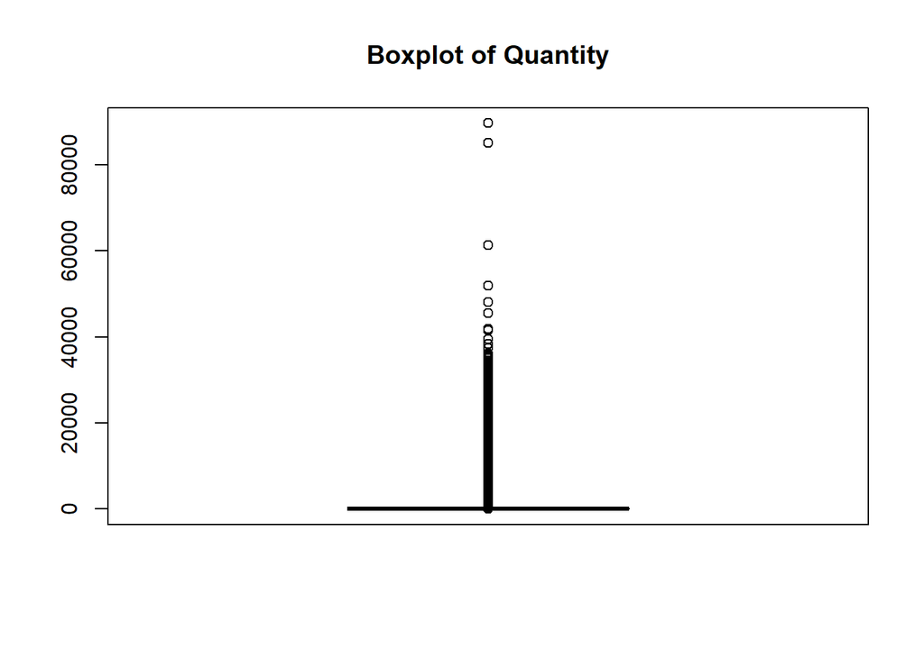

```r
# Checking the distribution of quantity
boxplot(transaction_data$quantity, main = "Boxplot of Quantity")
```

```r
# Quantile values
quantile(transaction_data$quantity, c(0.8, 0.9, 0.95, 0.98, 0.99))
```

```
## 80% 90% 95% 98% 99%
##   2   2   3   5  10
```

```r
# Calculating no. of rows for quantity>10
sum(transaction_data$quantity > 10)
```

```
## [1] 25406
```

As shown in Boxplot, the distribution of quantity column is highly skewed. After examining the values for multiple quantiles, it is evident that 99% of the values are below 10. There are total 25406 records with greater than 10 as quantity. In order to remove these anomalies, we will remove all reacords with less than zero and greater than 10 quantity value.

```r
# Checking the count
sum(transaction_data$quantity > 10 | transaction_data$quantity < 0)
```

```
## [1] 25406
```

```r
# Removing unwanted rows
transaction_data <- transaction_data %>% filter(quantity > 0 & quantity <= 10)

# Checking quantiles after cleaning
quantile(transaction_data$quantity, c(0.8, 0.9, 0.95, 0.98, 0.99, 1))
```

```
##  80%  90%  95%  98%  99% 100%
##    1    2    3    4    5   10
```

### Datasets preparation for Analysis

**Creating new columns: Quarter**

```r
# Creating quarter column
transaction_data$quarter <- quarter(as.Date(transaction_data$day - 1, origin = "2016-01-01"), with_year = TRUE)
```

We have created a new column: quarter to analyse the trend of transaction_data for each quarter.

**Creating new columns: Shelf Price**

```r
# Creating shelf price column
transaction_data <- transaction_data %>%
                mutate(shelf_price =
                       sales_value - retail_disc - coupon_disc - coupon_match_disc)
```

We have created a new column: shelf_price to see actual price of product without any discount.

**Selecting specific columns from datasets**

```r
# Selecting specific columns from transaction data
transaction_data <- transaction_data %>%
                select(household_key, basket_id, day, product_id, quantity,
                       sales_value,retail_disc, trans_time,
                       week_no, coupon_disc,coupon_match_disc,
                       quarter, shelf_price)

# Selecting specific columns from product data
product <- product %>%
           select(product_id, department, commodity_desc,sub_commodity_desc)
```

We have selected only those columns which are required for this analysis.

**Converting data types of columns: hh_demographic data set**

```r
# Converting categorical variables to factors

hh_demographic <- hh_demographic %>% mutate_if(is.character, factor)

# Checking the structure after conversion
str(hh_demographic)
```

```
## 'data.frame':    801 obs. of  8 variables:
##  $ household_key      : int  1 7 8 13 16 17 18 19 20 22 ...
##  $ age_desc           : Factor w/ 6 levels "19-24","25-34",..: 6 4 2 2 4 6 4 3 2 4 ...
##  $ marital_status_code: Factor w/ 3 levels "A","B","U": 1 1 3 3 2 2 1 2 1 1 ...
##  $ income_desc        : Factor w/ 12 levels "100-124K","125-149K",..: 9 10 7 11 10 12 1 3 11 11 ...
##  $ homeowner_desc     : Factor w/ 5 levels "Homeowner","Probable Owner",..: 1 1 5 1 1 1 1 5 4 1 ...
##  $ hh_comp_desc       : Factor w/ 6 levels "1 Adult Kids",..: 3 3 2 2 4 3 3 4 3 3 ...
##  $ household_size_desc: Factor w/ 5 levels "1","2","3","4",..: 2 2 3 4 1 2 2 1 2 2 ...
##  $ kid_category_desc  : Factor w/ 4 levels "1","2","3+","None/Unknown": 4 4 1 2 4 4 4 4 4 4 ...
```

We have converted all categorical variables of hh_demographic data to factors for the ease of the analysis. Description of selected datasets and columns will be provided in next section

### Summary of datasets selected and their varaibles after cleaning

**1. Transactions data** - Data about products bought in basket, quantity, value and discount (retail as well as manufacturer), transaction time, day and week

```r
# Creating a data frame with column names and types
transaction_vars <- data.frame(names(transaction_data), sapply(transaction_data, class),
                               row.names = NULL)
# Changing variable name of created data frame
colnames(transaction_vars) <- c("Variable Name", "Type")

# Providing description of variables
var_desc <-  c('Unique Identifier of household',
               'Unique identifier of transaction',
               'Day of transaction',
               'Unique identifier of product',
               'Units purchased in that transaction',
               'Amount of Dollars received by retailer',
               'Discount by retailer',
               'Transaction time of the day',
               'Week number of transaction. We have two-year worth data',
               'Discount applied due to Manufacturer discount',
               'Discount applied due to retailer match of manufacturer coupon',
               'Quarter of transaction. 4 quarters per year',
               'Actual price of product without discount')
var_desc           <- as.data.frame(var_desc)
colnames(var_desc) <- 'Variable Description'
transaction_vars   <- cbind(transaction_vars, var_desc)

# For summary of data
kable(data.frame(Obs = nrow(transaction_data), Variables = ncol(transaction_data)),
      caption = "Summary after cleaning")
```

Summary after cleaning

| Obs | Variables |
| --- | --- |
| 2555854 | 13 |

```r
kable(transaction_vars, caption = "Summary of transaction_data data")
```

Summary of transaction_data data

| Variable Name | Type | Variable Description |
| --- | --- | --- |
| household_key | integer | Unique Identifier of household |
| basket_id | numeric | Unique identifier of transaction |
| day | integer | Day of transaction |
| product_id | integer | Unique identifier of product |
| quantity | integer | Units purchased in that transaction |
| sales_value | numeric | Amount of Dollars received by retailer |
| retail_disc | numeric | Discount by retailer |
| trans_time | integer | Transaction time of the day |
| week_no | integer | Week number of transaction. We have two-year worth data |
| coupon_disc | numeric | Discount applied due to Manufacturer discount |
| coupon_match_disc | numeric | Discount applied due to retailer match of manufacturer coupon |
| quarter | numeric | Quarter of transaction. 4 quarters per year |
| shelf_price | numeric | Actual price of product without discount |

**2. Product data** - Data about product manufacturer, brand, department, category and sub category

```r
# Creating a data frame with column names
product_vars <- data.frame(names(product), sapply(product, class), row.names = NULL)
# Changing variable name of created data frame
colnames(product_vars) <-  c("Variable Name", "Type")

# Providing description of variables
var_desc <- c('Unique identifier of product',
               'Department under which product is grouped',
               'Can be considered as category of product',
               'Can be considered as sub category of product')
var_desc           <- as.data.frame(var_desc)
colnames(var_desc) <- 'Variable Description'
product_vars       <- cbind(product_vars, var_desc)

# For summary of data
kable(data.frame(Obs = nrow(product), Variables = ncol(product)),
      caption = "Summary after cleaning")
```

Summary after cleaning

| Obs | Variables |
| --- | --- |
| 92353 | 4 |

```r
kable(product_vars, caption = "Summary of Product data")
```

Summary of Product data

| Variable Name | Type | Variable Description |
| --- | --- | --- |
| product_id | integer | Unique identifier of product |
| department | character | Department under which product is grouped |
| commodity_desc | character | Can be considered as category of product |
| sub_commodity_desc | character | Can be considered as sub category of product |

**3. Household** - Data about age, marital status, income, homeowner, size and kids in household

```r
# Creating a data frame with column names
household_vars <- data.frame(names(hh_demographic), sapply(hh_demographic,class), row.names = NULL)
# Changing variable name of created data frame
colnames(household_vars) <-  c("Variable Name", "Type")

# Providing description of variables
var_desc <- c('Unique identifier of household',
              'Age description provided during registration of household',
              'Marital status provided during registration of household',
              'Income description provided during registration of household',
              'Home owning status provided during registration of household',
              'Household composition description provided during registration of Household',
              'Household size description provided during registration of household',
              'Kids decrption provided during registration of household')
var_desc           <- as.data.frame(var_desc)
colnames(var_desc) <- 'Description'
household_vars     <- cbind(household_vars, var_desc)

# For summary of data
kable(data.frame(Obs = nrow(hh_demographic), Variables = ncol(hh_demographic)),
      caption = "Summary after cleaning")
```

Summary after cleaning

| Obs | Variables |
| --- | --- |
| 801 | 8 |

```r
kable(household_vars, caption = "Summary of Household data")
```

Summary of Household data

| Variable Name | Type | Description |
| --- | --- | --- |
| household_key | integer | Unique identifier of household |
| age_desc | factor | Age description provided during registration of household |
| marital_status_code | factor | Marital status provided during registration of household |
| income_desc | factor | Income description provided during registration of household |
| homeowner_desc | factor | Home owning status provided during registration of household |
| hh_comp_desc | factor | Household composition description provided during registration of Household |
| household_size_desc | factor | Household size description provided during registration of household |
| kid_category_desc | factor | Kids decrption provided during registration of household |

**4. Campaign description** - Contains type of campaign, start and end day of campaign

```r
# Creating a data frame with column names
campaign_desc_vars <- data.frame(names(campaign_desc), sapply(campaign_desc,class), row.names = NULL)
# Changing variable name of created data frame
colnames(campaign_desc_vars) <-   c("Variable Name", "Type")

# Providing description of variables
var_desc <- c('Description of campaign',
               'Unique identifier for campaign',
               'Starting day of campaign',
               'Ending day of campaign')
var_desc           <- as.data.frame(var_desc)
colnames(var_desc) <- 'Description'
campaign_desc_vars <- cbind(campaign_desc_vars, var_desc)

# For summary of data

kable(data.frame(Obs = nrow(campaign_desc), Variables = ncol(campaign_desc)),
      caption = "Summary after cleaning")
```

Summary after cleaning

| Obs | Variables |
| --- | --- |
| 30 | 4 |

```r
kable(campaign_desc_vars, caption = "Summary of Campaign Description data")
```

Summary of Campaign Description data

| Variable Name | Type | Description |
| --- | --- | --- |
| description | character | Description of campaign |
| campaign | integer | Unique identifier for campaign |
| start_day | integer | Starting day of campaign |
| end_day | integer | Ending day of campaign |

**5. Campaign_table** - contains information about campaigns under which households were targeted. A household can receive multiple coupons as a part of single campaign. Data about coupons received by household is not present

```r
# Creating a data frame with column names
campaign_vars <- data.frame(names(campaign_table), sapply(campaign_table, class), row.names = NULL)
# Changing variable name of created data frame
colnames(campaign_vars) <-   c("Variable Name", "Type")

# Providing description of variables
var_desc <- c('Description of campaign',
              'Unique identifier for household',
              'Unique identifier of campaign under which a household was targeted')
var_desc           <- as.data.frame(var_desc)
colnames(var_desc) <- 'Description'
campaign_vars      <- cbind(campaign_vars, var_desc)

# For summary of data
kable(data.frame(Obs = nrow(campaign_table), Variables = ncol(campaign_table)),
      caption = "Summary after cleaning")
```

Summary after cleaning

| Obs | Variables |
| --- | --- |
| 7208 | 3 |

```r
kable(campaign_vars, caption = "Summary of Campaign data")
```

Summary of Campaign data

| Variable Name | Type | Description |
| --- | --- | --- |
| description | character | Description of campaign |
| household_key | integer | Unique identifier for household |
| campaign | integer | Unique identifier of campaign under which a household was targeted |

**6. Coupon** - Contains information about coupon code, products on which coupon code can be applied and campaign under which coupon was launched. There can be multiple products eligible for discount under single coupon

```r
# Creating a data frame with column names
coupon_vars <- data.frame(names(coupon), sapply(coupon, class), row.names = NULL)
# Changing variable name of created data frame
colnames(coupon_vars) <-   c("Variable Name", "Type")

# Providing description of variables
var_desc <- c('Unique identifier of coupon code',
              'Products on which discount can be applied through usage of coupon',
              'Unique identifier of campaign')
var_desc           <- as.data.frame(var_desc)
colnames(var_desc) <- 'Description'
coupon_vars        <- cbind(coupon_vars, var_desc)

# For summary of data
kable(data.frame(Obs = nrow(coupon), Variables = ncol(coupon)),
      caption = "Summary after cleaning")
```

Summary after cleaning

| Obs | Variables |
| --- | --- |
| 124548 | 3 |

```r
kable(coupon_vars, caption = "Summary of Coupon data")
```

Summary of Coupon data

| Variable Name | Type | Description |
| --- | --- | --- |
| coupon_upc | integer64 | Unique identifier of coupon code |
| product_id | integer | Products on which discount can be applied through usage of coupon |
| campaign | integer | Unique identifier of campaign |

**7. Coupon_redempt** - Contains information about coupons being used by households

```r
# Creating a data frame with column names
coupon_redempt_vars <- data.frame(names(coupon_redempt), sapply(coupon_redempt, class), row.names = NULL)
# Changing variable name of created data frame
colnames(coupon_redempt_vars) <- c("Variable Name", "Type")

# Providing description of variables
var_desc <- c('Unique identifier of household',
              'Day on which coupon was used to get discount',
              'Unique identifier of coupon code',
              'Unique identifier of campaign')
var_desc            <- as.data.frame(var_desc)
colnames(var_desc)  <- 'Description'
coupon_redempt_vars <- cbind(coupon_redempt_vars, var_desc)

# For summary of data
kable(data.frame(Obs = nrow(coupon_redempt), Variables = ncol(coupon_redempt)),
      caption = "Summary after cleaning")
```

Summary after cleaning

| Obs | Variables |
| --- | --- |
| 2318 | 4 |

```r
kable(coupon_redempt_vars, caption = "Summary of Coupon redempt data")
```

Summary of Coupon redempt data

| Variable Name | Type | Description |
| --- | --- | --- |
| household_key | integer | Unique identifier of household |
| day | integer | Day on which coupon was used to get discount |
| coupon_upc | integer64 | Unique identifier of coupon code |
| campaign | integer | Unique identifier of campaign |

## EDA and Market Basket Analysis

In this project we will be using data sets related to campaigns (campaign_desc, campaign_table, coupon and coupon_desc), transactions (transaction_data), products (product) and demographics (hh_demographic)

Below is the Exploratory Data Analysis

### EDA for Market Basket Analysis

**1. To determine timeframe of analysis and department**

Distribution of sales and trasactions across time

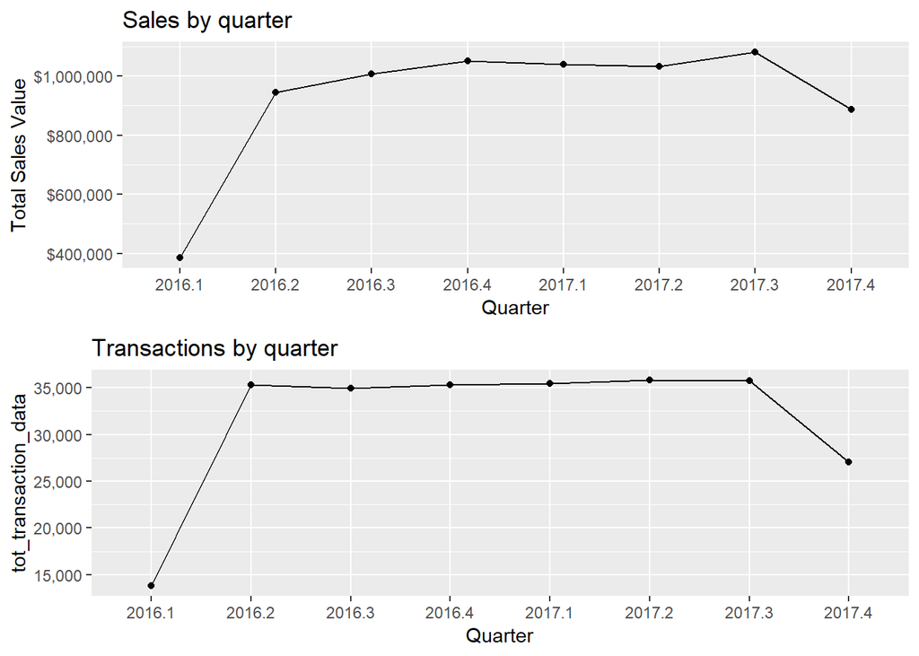

```r
# Sales by quarter
transaction_data$quarter <- as.factor(transaction_data$quarter)
sales_plot <- transaction_data %>%
              group_by(quarter) %>%
              summarise(tot_sales = sum(sales_value)) %>%
              ggplot(aes(x = quarter, y = tot_sales, group = 1)) +
              geom_point() +
              geom_line() +
              scale_y_continuous(name = "Total Sales Value", labels = scales::dollar) +
              labs(x = "Quarter", title = "Sales by quarter")

# Number of transaction_data by quarter
trans_plot <- transaction_data %>%
              group_by(quarter) %>%
              summarise(tot_transaction_data = n_distinct(basket_id)) %>%
              ggplot(aes(x = quarter, y = tot_transaction_data, group = 1)) +
              geom_point() +
              geom_line() +
              scale_y_continuous(labels = scales::comma) +
              labs(x = "Quarter", title = "Transactions by quarter")

# Plotting above plots in one window
grid.arrange(sales_plot, trans_plot, ncol = 1)
```

**Insights** - Could see that in Quarter 1 of 2016, sales and transactions are very low. This could be because of data quality issues

Distribution of sales across departments. We will be plotting for top 10 departments and all others will classified as ‘Others’

```r
# To identify top 10 departments by sales
top10_depts <- transaction_data %>%
               inner_join(product, by = "product_id") %>%
               group_by(department) %>%
               summarise(tot_sales = sum(sales_value)) %>%
               arrange(desc(tot_sales)) %>%
               top_n(10) %>%
               select(department)
```

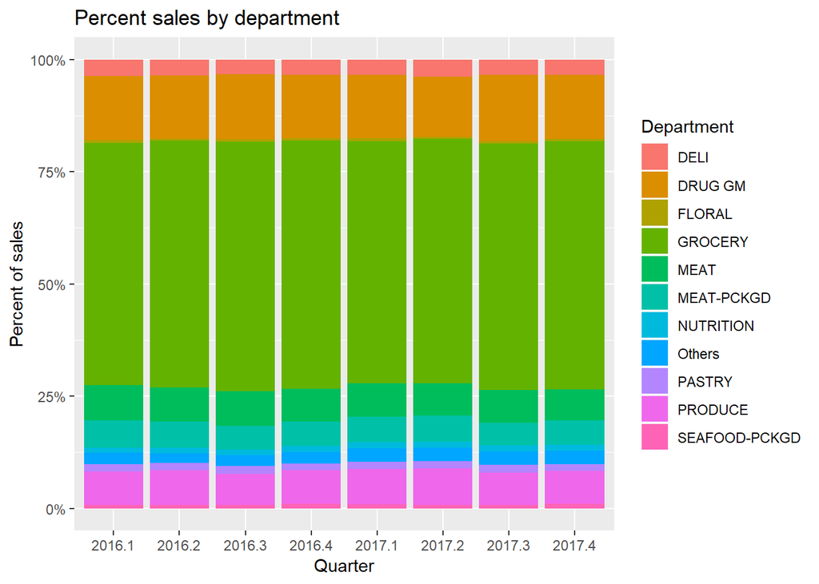

```r
top10_depts <- as.vector(top10_depts$department)

# Defining department - we will be considering top 10 by sales value and
# remaining all others under 'others' bucket
product$department2 <- ifelse(product$department %in%
                                top10_depts, product$department, 'Others')

# Making a join on product and transaction table
# Using data table for quick execution
prod_trans <- as.data.table(transaction_data %>%
                              inner_join(product, by = "product_id"))

# Creating a table which aggregates sales by department and quarter
sales_df <- as.data.table(prod_trans[,sum(sales_value),
                                     by = c("department2", "quarter")])

names(sales_df)[3] <- "sales_dept"

# Creating another variable sales_quarter which has sales in that quarter
sales_df[, sales_quarter := sum(sales_dept), by = "quarter"]
sales_df[, sales_dept_perc := (sales_dept / sales_quarter)*100,]

# Plotting sales by department. Stacked bar chart
dep_sales_plot <- sales_df %>%
                  ggplot(aes(x = quarter, y = sales_dept, fill = factor(department2))) +
                  geom_bar(stat = 'identity', position = "fill") +
                  scale_y_continuous(labels = scales::percent) +
                  labs(x = "Quarter", y = "Percent of sales",
                  title = "Percent sales by department") +
                  scale_fill_discrete(name = "Department")
dep_sales_plot
```

```r
# Remove sales_df object
rm(sales_df)
```

**Insights** - Could see that Grocery department was contributing to 50% of sales. We will be using the same for our Market Basket Analysis. Time frame of our analysis would be first two quarters of 2017 given consistency in sales across those two quarters

**2. To understand previous discount campaigns and response of the same in Grocery**

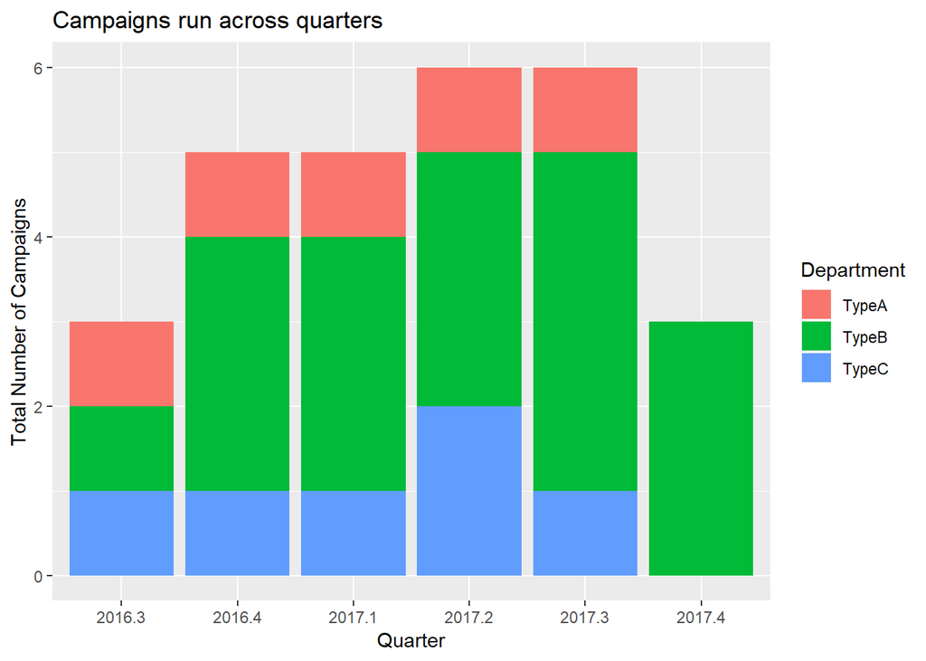

```r
#Creating a table which has details about campaigns run for different departments
campaign_coupon <- coupon %>%
                   inner_join(campaign_desc, by = "campaign") %>%
                   inner_join(product, by = "product_id") %>%
                   select(campaign, description, start_day, end_day, department, department2) %>%
                   filter(department2 == "GROCERY")

#For grocery department - Finding number of discount ran across months
#Creating a column called quarter
campaign_coupon$quarter <- as.factor(quarter(as.Date(campaign_coupon$start_day - 1,
                                                     origin = "2016-01-01"), with_year = TRUE))

#Creating discount plot
discount_plot <- campaign_coupon %>%
                 group_by(quarter, description) %>%
                 summarise(tot_campaigns = n_distinct(campaign)) %>%
                 ggplot(aes(x = quarter, y = tot_campaigns, fill = factor(description))) +
                 geom_bar(stat = 'identity') +
                 labs(x = "Quarter", y = "Total Number of Campaigns",
                 title = "Campaigns run across quarters") +
                 scale_fill_discrete(name = "Department")

discount_plot
```

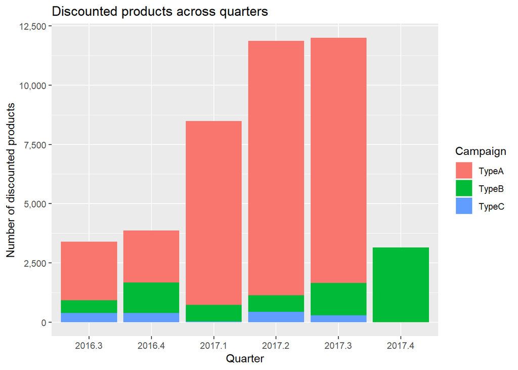

```r
#To find number of products in discount campaigns
prod_discount <- coupon %>%
                 inner_join(campaign_desc, by = "campaign") %>%
                 inner_join(product, by = "product_id") %>%
                 select(product_id, campaign, description, start_day,
                 end_day, department, department2) %>%
                 filter(department2 == "GROCERY")

#For grocery department - Finding number of products on discount across quarters
prod_discount$quarter <- as.factor(quarter(as.Date(prod_discount$start_day - 1,
                                                   origin = "2016-01-01"), with_year = TRUE))

#Plotting number of products under discount across quarters
prod_discount_plot <- prod_discount %>%
                      group_by(quarter, description) %>%
                      summarise(tot_products = n_distinct(product_id)) %>%
                      ggplot(aes(x = quarter, y = tot_products, fill = factor(description))) +
                      geom_bar(stat = 'identity') +
                      scale_y_continuous(labels = scales::comma) +
                      labs(x = "Quarter", y = "Number of discounted products",
                      title = "Discounted products across quarters") +
                      scale_fill_discrete(name = "Campaign")

prod_discount_plot
```

**Insights:** Could see that during 2017 Q4, only type B campaigns were run. Also, number of products under any of campaigns is the least in Q4 2017. This could be one of the reasons for dip in sales in Q4 2017. Couldn’t find any campaigns during first two quarters of 2016. Indicating that campaigns might have started only during Q3 of 2016 or data might not be available for first two quarters of 2016

**3. To understand frequency distribution of basket value and units being purchased in Grocery**

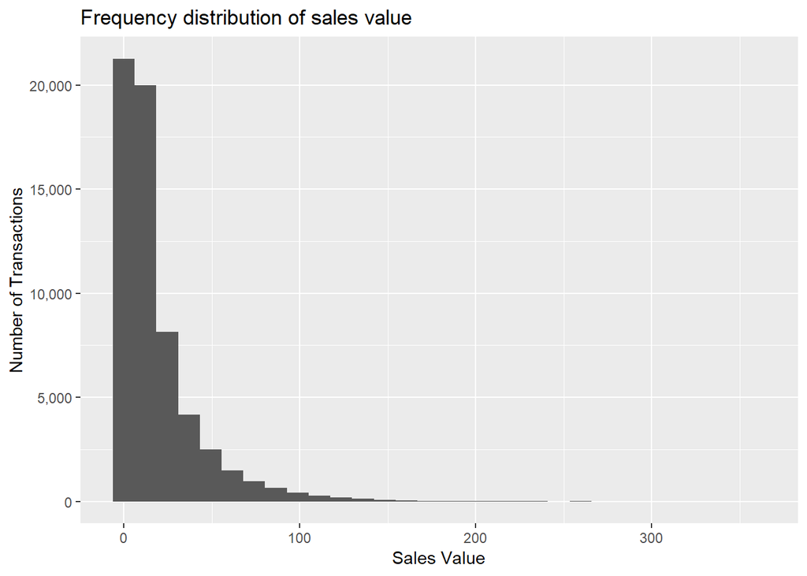

```r
# Joining product and transactions table
prod_trans <- prod_trans %>%
              filter(quarter %in% c('2017.1','2017.2'))

# Creating histogram for sales in grocery
sales_hist <- prod_trans %>%
              filter(department == 'GROCERY') %>%
              group_by(basket_id) %>%
              summarise(tot_sales = sum(sales_value)) %>%
              ggplot(aes(x = tot_sales)) +
              geom_histogram() +
              scale_y_continuous(labels = scales::comma) +
              labs(x = "Sales Value", y = "Number of Transactions",
              title = "Frequency distribution of sales value")

sales_hist
```

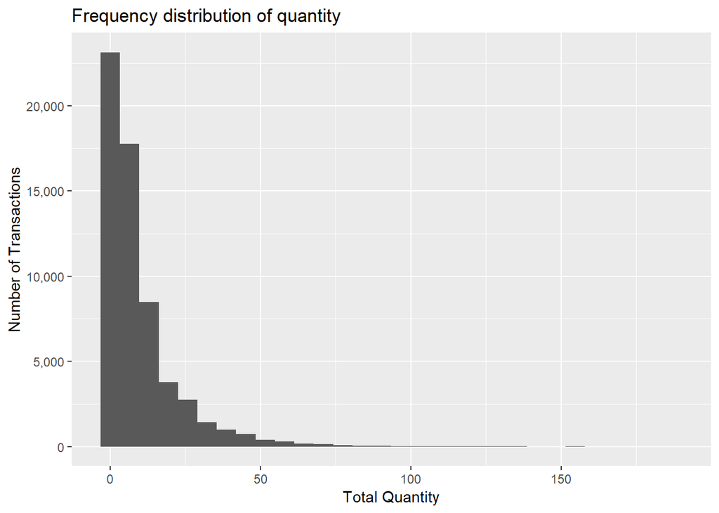

```r
# Creating histogram for sales in quantity
quantity_hist <- prod_trans %>%
                 filter(department == 'GROCERY') %>%
                 group_by(basket_id) %>%
                 summarise(tot_quantity = sum(quantity)) %>%
                 ggplot(aes(x = tot_quantity)) +
                 geom_histogram() +
                 scale_y_continuous(labels = scales::comma) +
                 labs(x = "Total Quantity", y = "Number of Transactions",
                 title = "Frequency distribution of quantity")
quantity_hist
```

**Insights:** Could see that both sales and quantity are right skewed. This indicates that there is a large proportion of customers who purchase less quanity and there are customers who would buy in high quanitites as well

**4. To understand top selling products in Grocery for first two quarters in 2017**

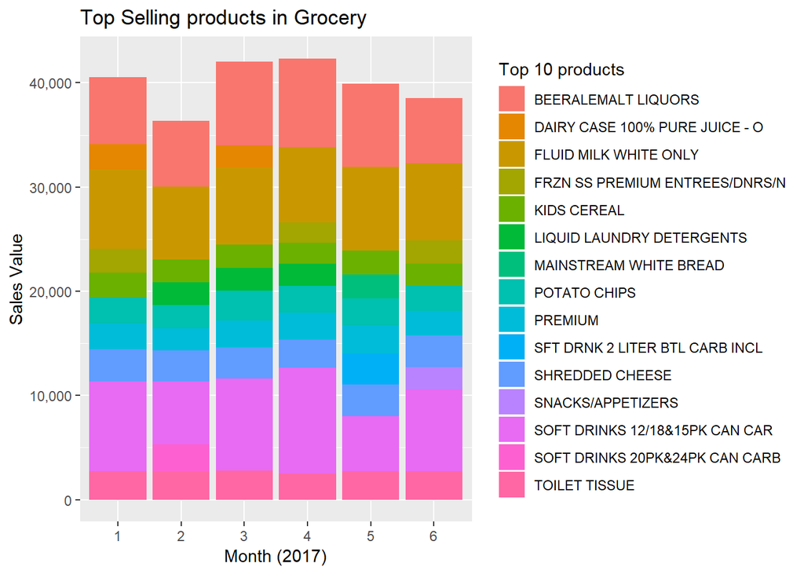

```r
# Creating a data frame filtered for Grocery department
prod_trans4 <- prod_trans[which(prod_trans$department == 'GROCERY'),]

# Creating month column
prod_trans4$month <- as.factor(month(as.Date(prod_trans4$day - 1, origin = "2016-01-01")))

# Creating a plot for sales of top 10 products in Grocery
top10_prod_sales <- prod_trans4 %>%
                    group_by(sub_commodity_desc, month) %>%
                    summarise(tot_sales = sum(sales_value)) %>%
                    group_by(month) %>%
                    top_n(10, wt = tot_sales) %>%
                    ggplot(aes(x = month, y = tot_sales, fill = factor(sub_commodity_desc))) +
                    geom_bar(stat = 'identity') +
                    scale_y_continuous(labels = scales::comma) +
                    labs(x = "Month (2017)", y = "Sales Value",
                    title = "Top Selling products in Grocery") +
                    scale_fill_discrete("Top 10 products")

top10_prod_sales
```

**Insights:** Could see that soft drinks and milk are top selling products in almost every month

### Running Market Basket Analysis Algorithm

**1. Creating dataset at transaction level**

```r
# Creating data set in transaction format
transaction_data_bask <- plyr::ddply(prod_trans4,c("basket_id"),
                                function(df1)paste(df1$sub_commodity_desc,
                                                   collapse = ","))

# There is no need of basket_id. Will be removing the same
transaction_data_bask <- transaction_data_bask[,2]
# Renaming second column
names(transaction_data_bask) <- "prod_combinations"

# Writing output in to CSV format
write.csv(transaction_data_bask, "data/transaction_data_bask.csv", quote = FALSE,
          row.names = TRUE)

# Reading in transactions format
basket_tr <- read.transactions("data/transaction_data_bask.csv", format = 'basket', sep = ',')
```

**2. Running Apriori Algorithm and plotting top 10 rules**

```r
# Running apriori algorithm
association.rules <- apriori(basket_tr, parameter = list(supp = 0.001, conf = 0.8, maxlen = 10))
```

```
## Apriori
##
## Parameter specification:
##  confidence minval smax arem  aval originalSupport maxtime support minlen
##         0.8    0.1    1 none FALSE            TRUE       5   0.001      1
##  maxlen target   ext
##      10  rules FALSE
##
## Algorithmic control:
##  filter tree heap memopt load sort verbose
##     0.1 TRUE TRUE  FALSE TRUE    2    TRUE
##
## Absolute minimum support count: 60
##
## set item appearances ...[0 item(s)] done [0.00s].
## set transactions ...[61039 item(s), 60361 transaction(s)] done [0.25s].
## sorting and recoding items ... [485 item(s)] done [0.01s].
## creating transaction tree ... done [0.03s].
## checking subsets of size 1 2 3 4 5 6 done [0.17s].
## writing ... [865 rule(s)] done [0.01s].
## creating S4 object  ... done [0.01s].
```

```r
# Getting top 10 sub rules
top10subRules <- head(association.rules, n = 10, by = "confidence")

# Plotting top 10 sub rules
plot(top10subRules, method = "graph",  engine = "htmlwidget")
```

[interactive chart not shown]

**3. Conclusions**

- **Rule 1:** If chocolate milk, eggs and cheese are being purchased in a basket, there is 97% chance of purchasing White milk
- **Rule 2:** If family cereal, eggs and peanut butter are being purchased in a basket, there is 95% chance of purchasing White milk
- **Rule 3:** IF eggs, potato chips, shredded cheese and soft drinks are being purchased, there is 94% chance of purchasing White milk
- Also, from other rules could see that if cereals and bread are being purchased together, there are high chances of purchasing White milk

## EDA and Clustering

### EDA for clustering

**1. Transaction Behaviour by Demographic Details**

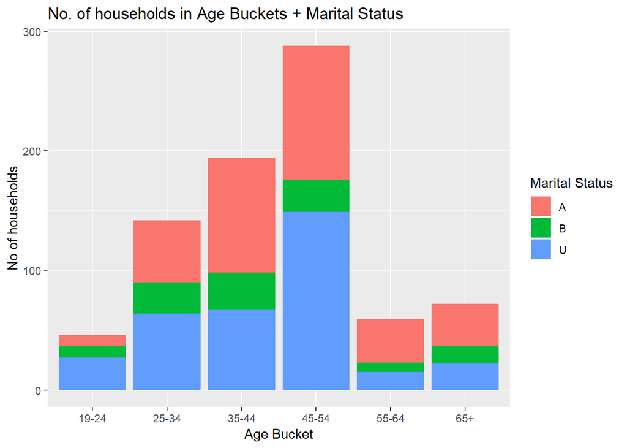

```r
# Combining Transaction data with Demographics data
trans_demo <- transaction_data %>%
              inner_join(hh_demographic, by = "household_key") %>%
              mutate(q = quarter(as.Date(day - 1, origin = "2016-01-01"))) %>%
              filter(q <= 2)

# No of Households Age Bucket Wise
Households_Age_Buckets <- trans_demo %>%
                          group_by(age_desc, marital_status_code) %>%
                          summarise(n_house = n_distinct(household_key)) %>%
                          ggplot(aes(x = age_desc, y = n_house, fill = marital_status_code)) +
                          geom_bar(stat = "identity") +
                          labs(title = "No. of households in Age Buckets + Marital Status",
                               x = "Age Bucket", y = "No of households") +
                          scale_fill_discrete("Marital Status")


Households_Age_Buckets
```

**Insights** - Majority of households are in 45-54 age category with very less no of unmarried houlseholds

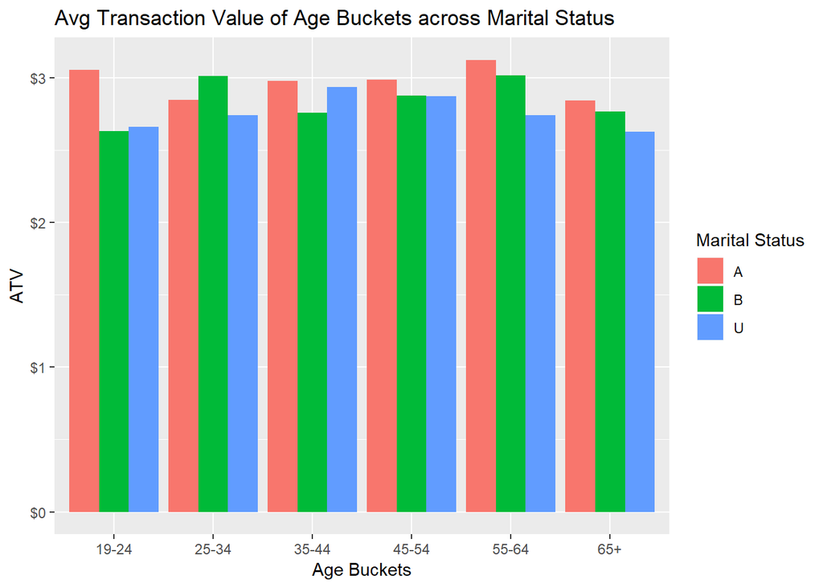

```r
# ATV Age bucket wise
ATV_Age_Buckets <-  trans_demo %>%
                    group_by(age_desc, marital_status_code) %>%
                    summarise(ATV = sum(sales_value)/n(),
                              ACV = sum(sales_value)/n_distinct(household_key)) %>%
                    ggplot(aes(x = age_desc, y = ATV, fill = marital_status_code)) +
                    geom_bar(stat = "identity", position = "dodge") +
                    labs(title = "Avg Transaction Value of Age Buckets across Marital Status",
                         x = "Age Buckets", y = "ATV") +
                    scale_y_continuous(labels = scales::dollar) +
                    scale_fill_discrete("Marital Status")

ATV_Age_Buckets
```

**Insights** - Households with marital status as married tend to spend more in all age buckets except 25-34

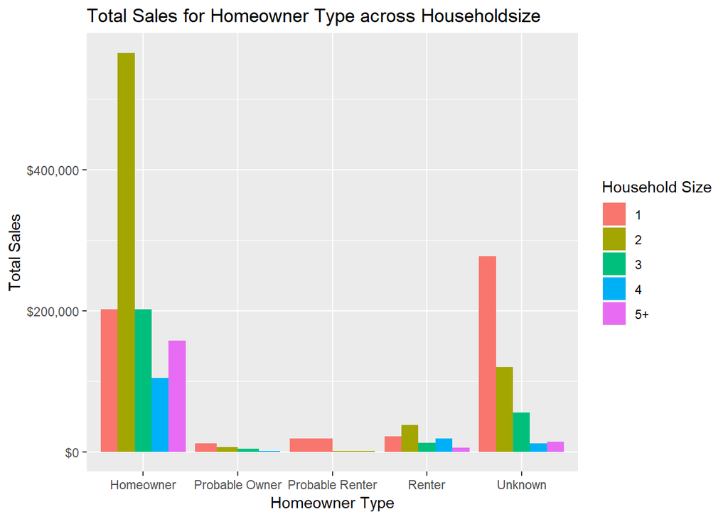

```r
# Sales by Household size
Sales_HouseSize <-  trans_demo %>%
                    group_by(household_size_desc, homeowner_desc) %>%
                    summarise(total_sale = sum(sales_value),
                              ATV = sum(sales_value)/n(),
                              ACV = sum(sales_value)/n_distinct(household_key)) %>%
                    ggplot(aes(x = homeowner_desc, y = total_sale, fill = household_size_desc)) +
                    geom_bar(stat = "identity", position = "dodge") +
                    labs(title = "Total Sales for Homeowner Type across Householdsize",
                         x = "Homeowner Type", y = "Total Sales") +
                    scale_y_continuous(labels = scales::dollar) +
                    scale_fill_discrete("Household Size")
Sales_HouseSize
```

**Insights** - People who are houseowner with household size = 2 are spending a lot as compared to other other household size buckets

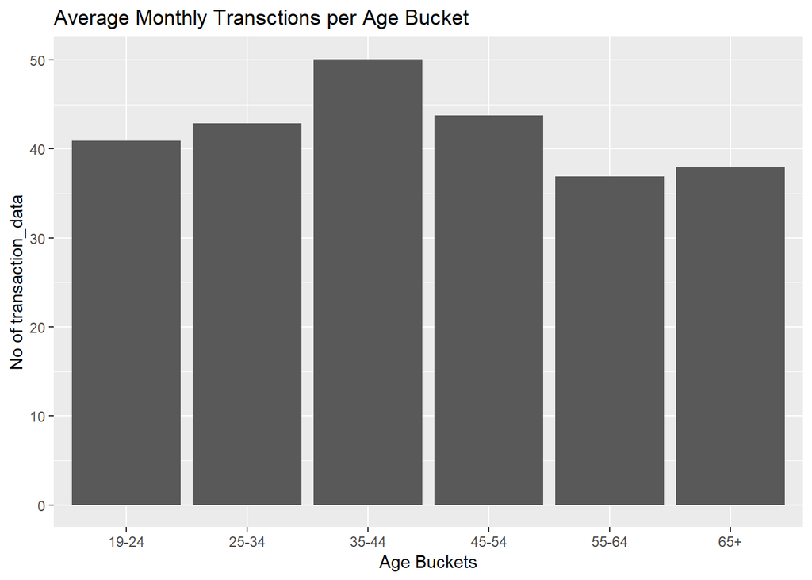

```r
# Purchance frequency
Purchase_Frequency <- trans_demo %>%
                      group_by(age_desc) %>%
                      summarise(trans = n(),
                                first = min(day),
                                last = max(day),
                                gap = last - first,
                                freq = trans/((gap/30) * n_distinct(household_key))) %>%
                      ggplot(aes(x = age_desc, y = freq)) +
                      geom_bar(stat = "identity") +
                      labs(title = "Average Monthly Transctions per Age Bucket",
                           x = "Age Buckets", y = "No of transaction_data")

Purchase_Frequency
```

**Insights** - Houshold with age bucket 35-44 are doing the maximun no of transaction_data in a month followed by 45-54 and 35-34 age buckets

**2. Response to Campaigns by Demographic Details**

```r
# Response of campaigns

# No of campaign sent
N_Campaigns <-  campaign_table %>%
                left_join(campaign_desc, by = "campaign") %>%
                mutate(q = quarter(as.Date(start_day - 1, origin = "2016-01-01"))) %>%
                filter(q <= 2) %>%
                group_by(household_key) %>%
                summarise(n_campaign = n_distinct(campaign))

# No of campaigns with response
Campaign_Response <-  coupon_redempt %>%
                      mutate(q = quarter(as.Date(day - 1, origin = "2016-01-01"))) %>%
                      filter(q <= 2) %>%
                      group_by(household_key) %>%
                      summarise(n_response = n_distinct(campaign))
# Response Rate
Response_Rate <-  N_Campaigns %>%
                  left_join(Campaign_Response, by = "household_key") %>%
                  mutate(percent_resp = n_response/n_campaign*100)
```

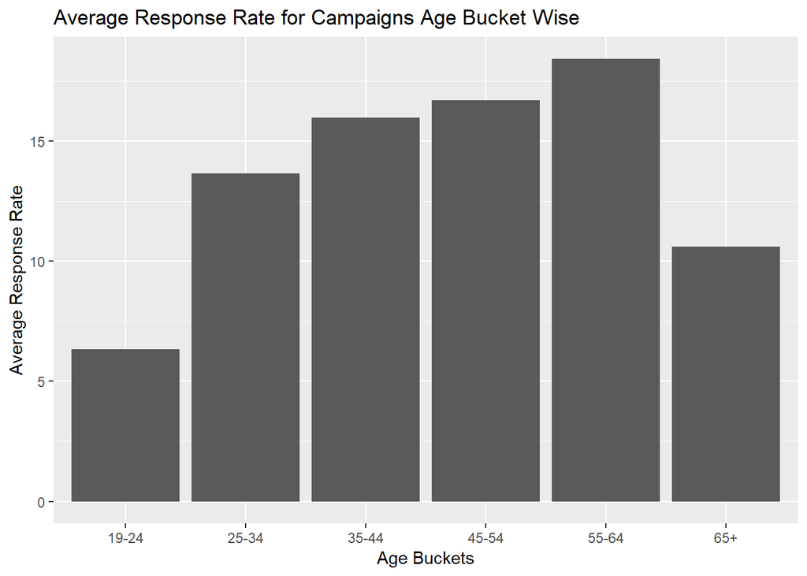

```r
# Replacing NAs
Response_Rate[is.na(Response_Rate)] <- 0

# Combining Demographic Data with Campaign Response
Response_Demo <-  Response_Rate %>%
                  inner_join(hh_demographic, by = "household_key")

# Campaign Response Age bucket wise
Response_Age <- Response_Demo %>%
                group_by(age_desc) %>%
                summarise(avg_resp = mean(percent_resp)) %>%
                ggplot(aes(x = age_desc, y = avg_resp)) +
                geom_bar(stat = "identity") +
                labs(title = "Average Response Rate for Campaigns Age Bucket Wise ",
                     x = "Age Buckets", y = "Average Response Rate")

Response_Age
```

**Insights** - Households from Age Bucket 55-64 has the highest average response rate and 19-24 age bucket has the least average response rate for campaigns

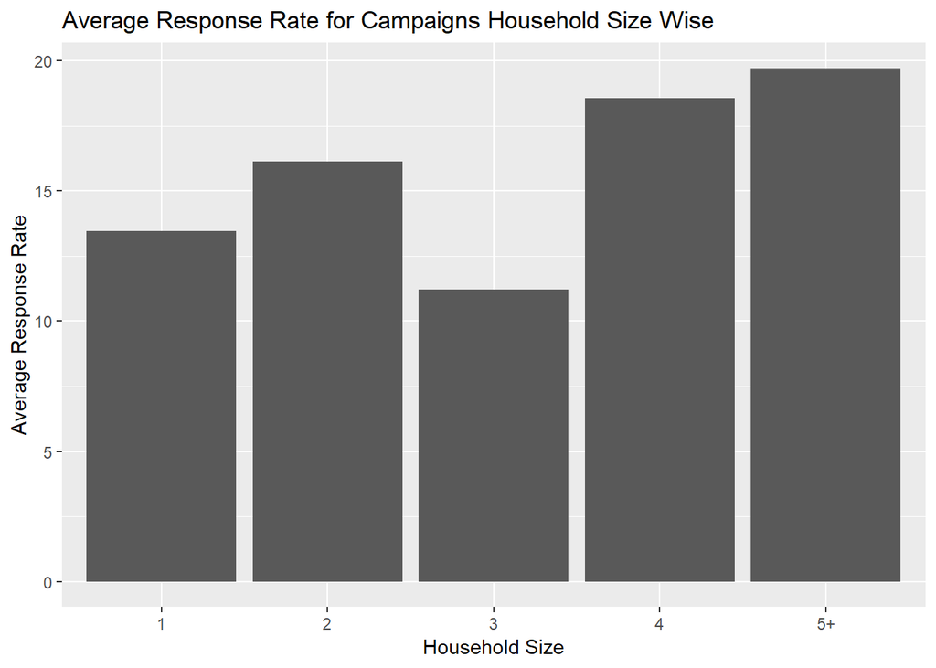

```r
#Response by Household size
Response_HSize <- Response_Demo %>%
                  group_by(household_size_desc) %>%
                  summarise(avg_resp = mean(percent_resp)) %>%
                  ggplot(aes(x = household_size_desc, y = avg_resp)) +
                  geom_bar(stat = "identity") +
                  labs(title = "Average Response Rate for Campaigns Household Size Wise ",
                       x = "Household Size", y = "Average Response Rate")

Response_HSize
```

**Insights** - Households with 5+ size had highest average response rate and 3 size had the least average response rate for campaigns

### Performing clustering

**1. Creating dataset required for clustering**

```r
# Creating data frame of sales. Summarize at household level
sales_value_df <- prod_trans %>%
                  group_by(household_key) %>%
                  summarise(tot_sales = sum(sales_value),
                  tot_quantity = sum(quantity),
                  tot_sales_disc = sum(shelf_price) - sum(sales_value),
                  tot_transactions = n_distinct(basket_id))

# Creating data frame for sales in Grocery department
sales_value_groc_df <- prod_trans %>%
                       filter(department2 == 'GROCERY') %>%
                       group_by(household_key) %>%
                       summarise(tot_sales_groc = sum(sales_value),
                       tot_quantity_groc = sum(quantity),
                       tot_sales_disc_groc = sum(shelf_price) - sum(sales_value))

# Creating campaign description table
camp_desc <- campaign_table %>%
             left_join(campaign_desc, by = "campaign") %>%
             mutate(q = quarter(as.Date(start_day - 1, origin = "2016-01-01"))) %>%
             filter(q <= 2) %>%
             group_by(household_key) %>%
             summarise(n_campaign = n_distinct(campaign))

# Creating coupon description table
coupon_desc <- coupon_redempt %>%
               group_by(household_key) %>%
               summarise(n_response = n_distinct(campaign))

# Joining above two tables
camp_coupon <- camp_desc %>%
               left_join(coupon_desc, by = "household_key") %>%
               mutate(percent_resp = n_response/n_campaign*100)

camp_coupon[is.na(camp_coupon)] <- 0

# Creating tables for median days difference between transactions
# Selecting only required columns and distinct rows
prod_trans2 <- as.data.table(prod_trans %>%
                               select(household_key, day, quarter) %>%
                               distinct())

# Creating column rank
prod_trans2[, trans_rank := rank(day), by = household_key]

#Creating column next_rank. Will be using for self join
prod_trans2$next_rank <- prod_trans2$trans_rank - 1

# Doing a self join on household_key and rank
prod_trans3 <- prod_trans2 %>%
  inner_join(prod_trans2, by = c("household_key" = "household_key",
                                 "trans_rank" = "next_rank"))

#Creating days difference column
prod_trans3$days_diff <- prod_trans3$day.y - prod_trans3$day.x

# Creating a data frame which can be used as input to clustering
clustering_df <- prod_trans3 %>%
                 group_by(household_key) %>%
                 summarise(median_diff = median(days_diff)) %>%
                 inner_join(sales_value_df, by = "household_key") %>%
                 inner_join(sales_value_groc_df, by = "household_key") %>%
                 left_join(camp_coupon, by = "household_key")
```

In this phase we will be concentrating majorly on continuous variables. Will be extending the same to categorical in next phase

**2. Determining number of clusters**

We will be using Elbow method (Total Sum of squares) and silhouette width to determine the same

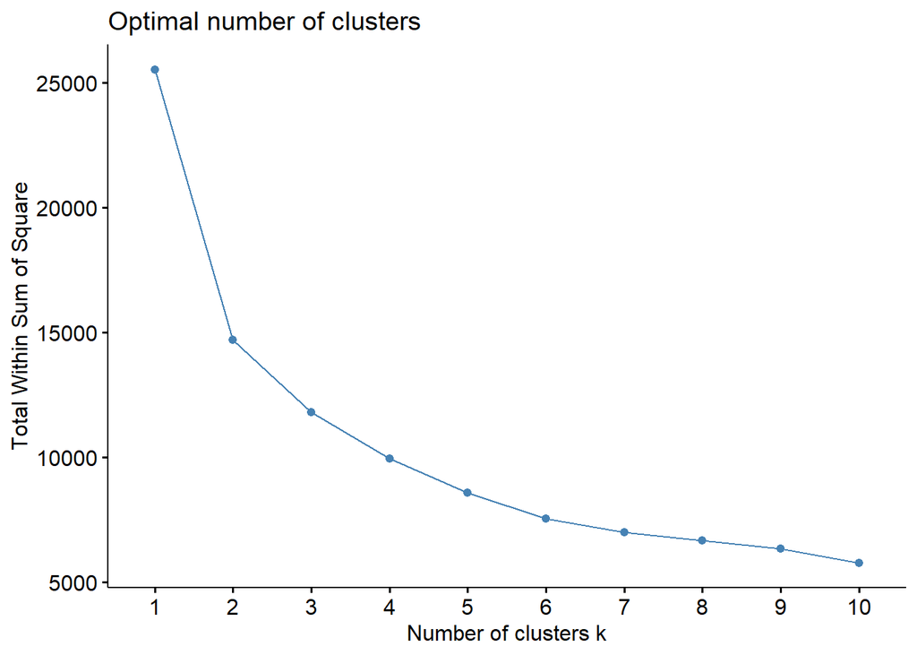

```r
# Replacing na with 0
clustering_df[is.na(clustering_df)] <- 0

# Scaling clustering_df
clustering_df_scaled <- scale(clustering_df[,-1])

# Plotting number of clusters and total of distances
fviz_nbclust(clustering_df_scaled, kmeans, method = "wss")
```

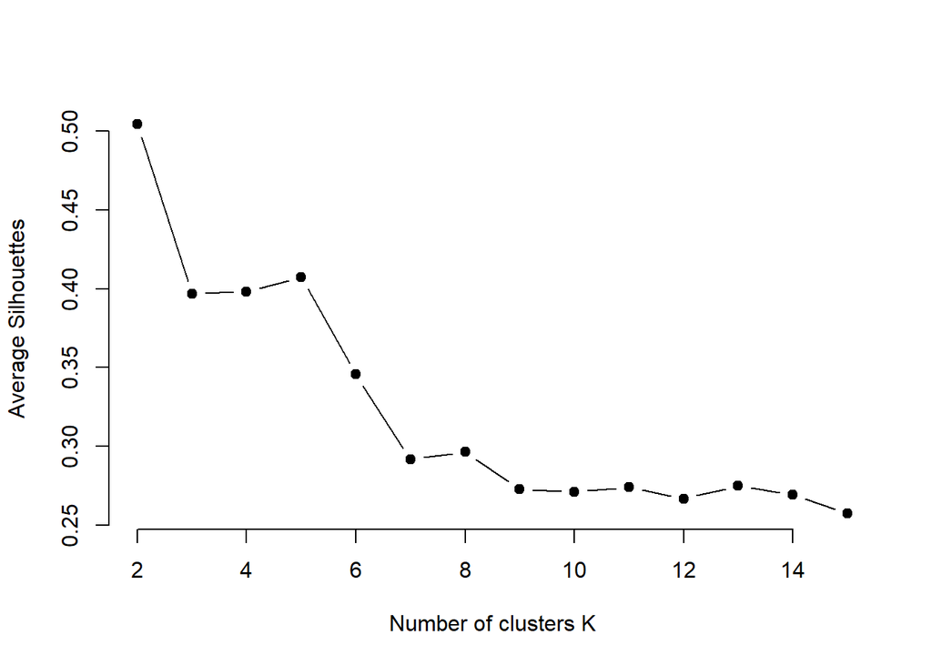

```r
# Creating function for average silhouette width
avg_sil <- function(k) {
  km.res <- kmeans(clustering_df_scaled, centers = k, nstart = 25)
  ss <- silhouette(km.res$cluster, dist(clustering_df_scaled))
  mean(ss[, 3])
}

k.values <- 2:15

# Extract avg silhouette for 2-15 clusters
avg_sil_values <- map_dbl(k.values, avg_sil)

# Plot silhouette width for different clusters
plot(k.values, avg_sil_values,
     type = "b", pch = 19, frame = FALSE,
     xlab = "Number of clusters K",
     ylab = "Average Silhouettes")
```

Will be chossing number of clusters to be four

**3. Running Clustering Algorithm**

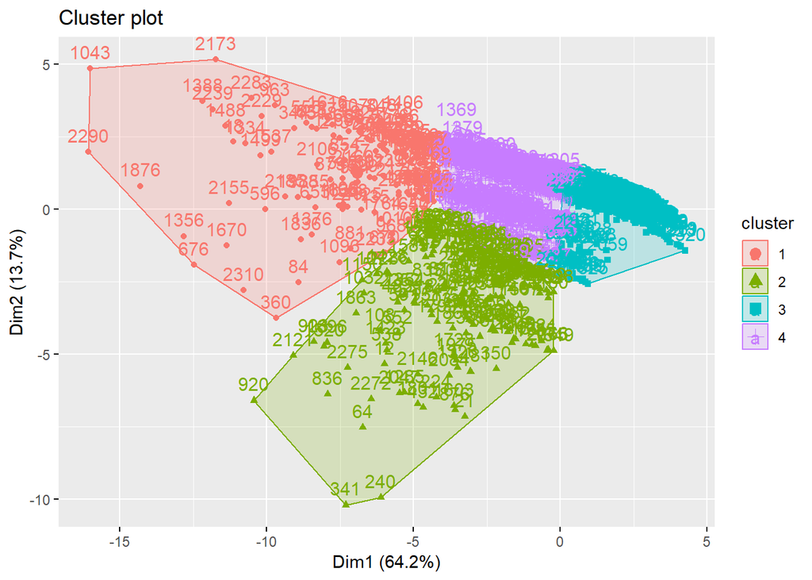

```r
# Run clustering with nclust = 4
kmeans_output <- kmeans(clustering_df_scaled, centers = 4, nstart = 25)

# Visualizing clustering
fviz_cluster(kmeans_output, clustering_df_scaled)
```

```r
# Compute and plot wss for k = 2 to k = 15
clustering_df <- cbind(clustering_df, kmeans_output$cluster)
names(clustering_df)[13] <- "cluster"

# Output group by cluster
output <- clustering_df %>%
          group_by(cluster) %>%
          summarise(
            tot_cust = n(),
            med_days_diff = median(median_diff),
            med_tot_sales = median(tot_sales),
            med_tot_quantity = median(tot_quantity),
            med_tot_sales_disc = median(tot_sales_disc),
            med_tot_transactions = median(tot_transactions),
            med_tot_sales_groc = median(tot_sales_groc),
            med_tot_quantity_groc = median(tot_quantity_groc)
          )

kable(output)
```

| cluster | tot_cust | med_days_diff | med_tot_sales | med_tot_quantity | med_tot_sales_disc | med_tot_transactions | med_tot_sales_groc | med_tot_quantity_groc |
| --- | --- | --- | --- | --- | --- | --- | --- | --- |
| 1 | 130 | 2.0 | 3107.265 | 1360 | 620.865 | 78.5 | 1721.765 | 892.0 |
| 2 | 167 | 4.0 | 1479.730 | 701 | 331.050 | 40.0 | 854.500 | 460.0 |
| 3 | 1396 | 8.5 | 306.925 | 138 | 57.355 | 13.0 | 159.865 | 85.0 |
| 4 | 628 | 4.0 | 1273.040 | 589 | 236.985 | 39.0 | 697.375 | 371.5 |

**4. Profiling and conclusions**

## Recommendations and Next Steps

- From Market Basket Analysis, found that if Cereals and Bread are in a basket, Milk is high likely to be purchased. Could use the same for shelf assortment i.e. placing these three products in nearby shelves
- For customers under segments Normal buyers and Heavy buyers can offer discount on product bundle i.e. offering discount if they are to purchase Milk, Cereals and Bread together
- Need to design A/B testing methodology to test out above two recommendations in first phase
- Since this is first phase of this project, we are limiting to very few rules from market basket analysis. Based on results from A/B testing, would be extending the same to other rules as well

### Machine Learning Techniques

Used [Market Basket Analyis](https://datascienceplus.com/a-gentle-introduction-on-market-basket-analysis%E2%80%8A-%E2%80%8Aassociation-rules/) based on Apriori algorithm and [K-Means Clustering](https://www.r-bloggers.com/k-means-clustering-in-r/), an unsupervised machine learning algorithm.